We were asked to analyze the Tooth Growth dataset in R. From the R help file: “the response is the length of odontoblasts (teeth) in each of 10 guinea pigs at each of three dose levels of Vitamin C (0.5, 1, and 2 mg) with each of two delivery methods (orange juice or ascorbic acid).” The variable “len” is the tooth length in mm, “supp” is the supplement type delivery method (OJ = orange juice, VC = ascorbic acid), and “dose” is the dose level of vitamin C (0.5, 1, 2 mg).

**Exploratory Data Analysis**

There are a total of 60 observations in this dataset. A summary of the data can be seen below.

```r
library(plyr)
summary(ToothGrowth)
```

```
##       len        supp         dose
##  Min.   : 4.20   OJ:30   Min.   :0.500
##  1st Qu.:13.07   VC:30   1st Qu.:0.500
##  Median :19.25           Median :1.000
##  Mean   :18.81           Mean   :1.167
##  3rd Qu.:25.27           3rd Qu.:2.000
##  Max.   :33.90           Max.   :2.000
```

```r
ddply(ToothGrowth,"supp",summarize, avg=mean(len))
```

```
##   supp      avg
## 1   OJ 20.66333
## 2   VC 16.96333
```

```r
ddply(ToothGrowth,"supp",summarize, StDev=sd(len))
```

```
##   supp    StDev
## 1   OJ 6.605561
## 2   VC 8.266029
```

```r
ddply(ToothGrowth,"dose",summarize, avg=mean(len))
```

```
##   dose    avg
## 1  0.5 10.605
## 2  1.0 19.735
## 3  2.0 26.100
```

```r
ddply(ToothGrowth,"dose",summarize, StDev=sd(len))
```

```
##   dose    StDev
## 1  0.5 4.499763
## 2  1.0 4.415436
## 3  2.0 3.774150
```

```r
ddply(ToothGrowth,c("supp","dose"),summarize, avg=mean(len))
```

```
##   supp dose   avg
## 1   OJ  0.5 13.23
## 2   OJ  1.0 22.70
## 3   OJ  2.0 26.06
## 4   VC  0.5  7.98
## 5   VC  1.0 16.77
## 6   VC  2.0 26.14
```

```r
ddply(ToothGrowth,c("supp","dose"),summarize, StDev=sd(len))
```

```
##   supp dose    StDev
## 1   OJ  0.5 4.459709
## 2   OJ  1.0 3.910953
## 3   OJ  2.0 2.655058
## 4   VC  0.5 2.746634
## 5   VC  1.0 2.515309
## 6   VC  2.0 4.797731
```

The first plot shows the tooth length by supplement type. From the boxplot, it appears that they are not very dissimilar.

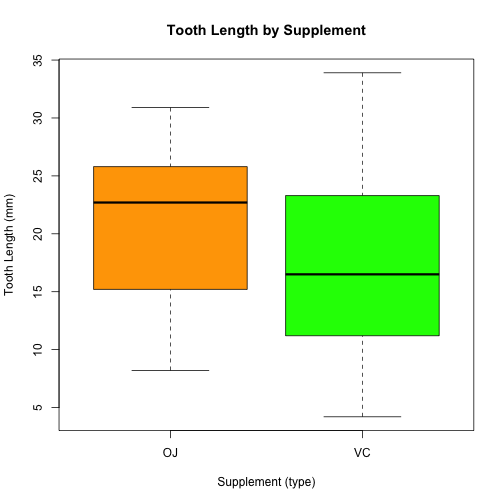

```r
boxplot(ToothGrowth$len~ToothGrowth$supp,col=c("orange","green"),
        main="Tooth Length by Supplement",ylab="Tooth Length (mm)",
        xlab="Supplement (type)")
```

The next plot shows the tooth length by dose, 0.5, 1, and 2 mg. There does appear to be a difference between these, especially between the 0.5 and 2 mg doses.

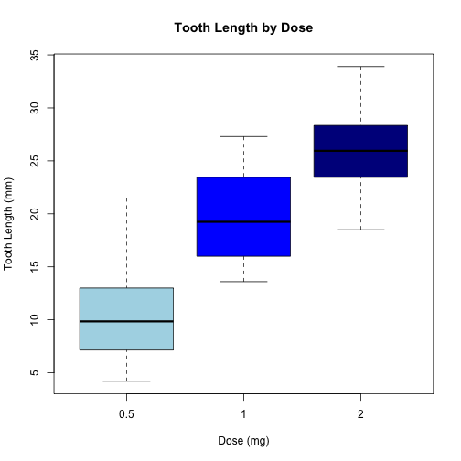

```r
boxplot(ToothGrowth$len~ToothGrowth$dose,col=c("lightblue",
                                               "blue","darkblue"),
        main="Tooth Length by Dose",ylab="Tooth Length (mm)",xlab="Dose (mg)")
```

The next plot shows the interaction between dose and supplement type. When dose is considered, it appears that both supplement types increase the tooth length.

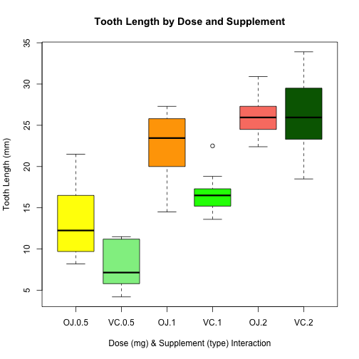

```r
boxplot(len ~ interaction(supp,dose), data=ToothGrowth,
        col=c("yellow","lightgreen","orange","green","salmon","darkgreen"),
        main="Tooth Length by Dose and Supplement",ylab="Tooth Length (mm)",
        xlab="Dose (mg) & Supplement (type) Interaction")
```

*Hypothesis Tests*

```r
# T test for Supplement type
VC=subset(ToothGrowth, supp=="VC")
OJ=subset(ToothGrowth,supp=="OJ")
t.test(VC$len,OJ$len)
```

```
##
##  Welch Two Sample t-test
##
## data:  VC$len and OJ$len
## t = -1.9153, df = 55.309, p-value = 0.06063
## alternative hypothesis: true difference in means is not equal to 0
## 95 percent confidence interval:
##  -7.5710156  0.1710156
## sample estimates:
## mean of x mean of y
##  16.96333  20.66333
```

```r
# T test for doses
dose0.5=subset(ToothGrowth,dose==0.5)
dose2=subset(ToothGrowth,dose==2.0)
t.test(dose0.5$len,dose2$len)
```

```
##
##  Welch Two Sample t-test
##
## data:  dose0.5$len and dose2$len
## t = -11.799, df = 36.883, p-value = 4.398e-14
## alternative hypothesis: true difference in means is not equal to 0
## 95 percent confidence interval:
##  -18.15617 -12.83383
## sample estimates:
## mean of x mean of y
##    10.605    26.100
```

```r
tdose=round(t.test(dose0.5$len,dose2$len)$p.value,14)

dose0.5=subset(ToothGrowth,dose==0.5)
dose1=subset(ToothGrowth,dose==1.0)
t.test(dose0.5$len,dose1$len)
```

```
##
##  Welch Two Sample t-test
##
## data:  dose0.5$len and dose1$len
## t = -6.4766, df = 37.986, p-value = 1.268e-07
## alternative hypothesis: true difference in means is not equal to 0
## 95 percent confidence interval:
##  -11.983781  -6.276219
## sample estimates:
## mean of x mean of y
##    10.605    19.735
```

```r
t.test(dose1$len,dose2$len)
```

```
##
##  Welch Two Sample t-test
##
## data:  dose1$len and dose2$len
## t = -4.9005, df = 37.101, p-value = 1.906e-05
## alternative hypothesis: true difference in means is not equal to 0
## 95 percent confidence interval:
##  -8.996481 -3.733519
## sample estimates:
## mean of x mean of y
##    19.735    26.100
```

```r
# T test for supplement and dose
VCdose.5=subset(ToothGrowth,dose==0.5 & supp=="VC")
OJdose.5=subset(ToothGrowth,dose==0.5 & supp=="OJ")
t.test(VCdose.5$len,OJdose.5$len)
```

```
##
##  Welch Two Sample t-test
##
## data:  VCdose.5$len and OJdose.5$len
## t = -3.1697, df = 14.969, p-value = 0.006359
## alternative hypothesis: true difference in means is not equal to 0
## 95 percent confidence interval:
##  -8.780943 -1.719057
## sample estimates:
## mean of x mean of y
##      7.98     13.23
```

```r
VCdose1=subset(ToothGrowth,dose==1.0 & supp=="VC")
OJdose1=subset(ToothGrowth,dose==1.0 & supp=="OJ")
t.test(VCdose1$len,OJdose1$len)
```

```
##
##  Welch Two Sample t-test
##
## data:  VCdose1$len and OJdose1$len
## t = -4.0328, df = 15.358, p-value = 0.001038
## alternative hypothesis: true difference in means is not equal to 0
## 95 percent confidence interval:
##  -9.057852 -2.802148
## sample estimates:
## mean of x mean of y
##     16.77     22.70
```

```r
VCdose2=subset(ToothGrowth,dose==2.0 & supp=="VC")
OJdose2=subset(ToothGrowth,dose==2.0 & supp=="OJ")
t.test(VCdose2$len,OJdose2$len)
```

```
##
##  Welch Two Sample t-test
##
## data:  VCdose2$len and OJdose2$len
## t = 0.0461, df = 14.04, p-value = 0.9639
## alternative hypothesis: true difference in means is not equal to 0
## 95 percent confidence interval:
##  -3.63807  3.79807
## sample estimates:
## mean of x mean of y
##     26.14     26.06
```

Almost all of the t-tests performed resulted in significant differences in the means of the tooth length at the p=0.05 level.

We have strong evidence that dose results in different mean lengths for teeth. Between the 0.5 and 2.0 mg dose, a p-value of less than 0.000000001 is produced. This is highly significant.

When dose and supplement are considered, there are two significant difference at the 0.5 and 1.0 mg dose levels, between supplement types. The p-values for these tests (dose of 0.5 mg, by supplement type and dose of 1.0 mg, by supplement type) were 0.0063586 and 0.0010384 respectively.

**Conclusion**

Overall, we can conclude that as the dose of vitamin C increases, so does the tooth length. The supplement type only appears to play a significant role at the 0.5 and 1.0 mg dose levels.